# **Numpy**

- NumPy stands for Numerical Python and
- Numpy is linear algebra library for python.
- Numpy is incredibly fast.
- NumPy handles large datasets effectively and efficiently
- Provides support for **large multidimensional array objects**.

  **Array**
  - Arrays are a collection of elements/values, that can have one or more dimensions.
    - An array of one dimension is called a **Vector**
    - while having two dimensions is called a **Matrix**.
- NumPy arrays are called **ndarray** or **N-dimensional arrays** and

  ```
                *They store elements of the same type*
  ```

Note:

> Numpy is know for **high-performance** and provides **efficient storage and data operations** as *arrays grow in size.*

### **Python Lists vs NumPy Arrays – What’s the Difference?**

- When you want list of homogeneous elements of large size and frees memory faster(10x to 100x).
  - NumPy arrays is solution not list.

#### Creating ndarrays

- 1D arrays can be be described simply by the number of values they contain.
- The dimensions of a 2D array are described by the number of rows and columns in the array.numpy describes 2D arrays by first listing the number of rows then the number columns.
- The dimensions of a 3D array are described by the number of layers the array contains, and the number of rows and columns in each layer. All layers must have the same number of rows and columns. numpy reports the shape of 3D arrays in the order layers, rows, column

### **Size of NumPy array**

- determine how many values there are in the array using the size attribute
- It just multiplies the number of *rows* by the number of *columns* in the ndarray:

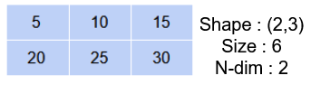

## **Creating a NumPy Array**

#### **. Creating 1D NumPy Array**

```python
import numpy as np
#!pip install numpy
```

```python
a = np.array([1,2,3,4,5,6]) # 1 D array
a
```

```
array([1, 2, 3, 4, 5, 6])
```

```python
a.size # no. of elements
```

```
6
```

```python
a.ndim # dimension of array
```

```
1
```

```python
a.shape
```

```
(6,)
```

```python
b = np.array([[1,2],[3,4]]) # 2D array
b
```

```
array([[1, 2],
       [3, 4]])
```

```python
b.size # size of array
```

```
4
```

```python
b.shape
```

```
(2, 2)
```

```python
b.shape[0] * b.shape[1]  # size of array
```

```
4
```

```python
b.ndim
```

```
2
```

```python
c = np.array([[[1,2],[3,4]],[[1,2],[3,4]]]) # 3D array
c
```

```
array([[[1, 2],
        [3, 4]],

       [[1, 2],
        [3, 4]]])
```

```python
c.size
```

```
8
```

```python
c.shape
```

```
(2, 2, 2)
```

```python
c.ndim
```

```
3
```

**If heterogenous data entered?**

- values will be upcast if the types do not match:

```python
a = np.array([1,2.5,3,4.8,2])
a
```

```
array([1. , 2.5, 3. , 4.8, 2. ])
```

```python
a.dtype
```

```
dtype('float64')
```

```python
a = np.array([1,2.5,3,4.8,2],dtype='int')
a
```

```
array([1, 2, 3, 4, 2])
```

```python
a.dtype
```

```
dtype('int32')
```

#### Creating array of zeros and ones

```python
np.zeros(3)
```

```
array([0., 0., 0.])
```

```python
np.zeros((2,3))
```

```
array([[0., 0., 0.],
       [0., 0., 0.]])
```

```python
np.ones(4)
```

```
array([1., 1., 1., 1.])
```

```python
np.ones((4,4))
```

```
array([[1., 1., 1., 1.],
       [1., 1., 1., 1.],
       [1., 1., 1., 1.],
       [1., 1., 1., 1.]])
```

```python
# Create a 5x5 matrix of all 5's
np.ones((5,5))*5
```

```
array([[5., 5., 5., 5., 5.],
       [5., 5., 5., 5., 5.],
       [5., 5., 5., 5., 5.],
       [5., 5., 5., 5., 5.],
       [5., 5., 5., 5., 5.]])
```

```python
np.full((5,5),5) # constant matrix
```

```
array([[5, 5, 5, 5, 5],
       [5, 5, 5, 5, 5],
       [5, 5, 5, 5, 5],
       [5, 5, 5, 5, 5],
       [5, 5, 5, 5, 5]])
```

```python
# Identity matrix
np.eye(4,4)
```

```
array([[1., 0., 0., 0.],
       [0., 1., 0., 0.],
       [0., 0., 1., 0.],
       [0., 0., 0., 1.]])
```

```python
# Random numbers
np.random.rand(5) #1D array
```

```
array([0.25986871, 0.58260211, 0.3104237 , 0.96336396, 0.28182093])
```

```python
np.random.rand(3,4) # 2D array
```

```
array([[0.03538878, 0.43195088, 0.50131339, 0.90430483],
       [0.8162698 , 0.67406161, 0.65304881, 0.6222277 ],
       [0.36911841, 0.148537  , 0.53391114, 0.81252374]])
```

```python
np.random.rand(2,3,4) #3D array
```

```
array([[[0.12299156, 0.41250737, 0.99678289, 0.03331421],
        [0.12347128, 0.42197858, 0.12426889, 0.31420734],
        [0.47894686, 0.26969622, 0.8643335 , 0.27109822]],

       [[0.46989724, 0.23087654, 0.76645365, 0.71967851],
        [0.87407715, 0.59698659, 0.82752992, 0.51551326],
        [0.45441385, 0.93199224, 0.82800759, 0.61908385]]])
```

```python
np.random.randint(7)
```

```
4
```

```python
np.random.randint(3,17,size=(2,4))
```

```
array([[ 9, 11, 14, 13],
       [ 4, 11,  7,  4]])
```

```python
np.random.seed(0)
np.random.randint(3,17,size=(2,4))
```

```
array([[15,  8,  3,  6],
       [14,  6, 10, 12]])
```

```python
np.arange(10)
```

```
array([0, 1, 2, 3, 4, 5, 6, 7, 8, 9])
```

```python
np.arange(1,10,2)
```

```
array([1, 3, 5, 7, 9])
```

```python
# 20 to 10 using arange
np.arange(20,10,-1)
```

```
array([20, 19, 18, 17, 16, 15, 14, 13, 12, 11])
```

```python
# Convert 1D array to n-d arrays
```

```python
a = np.array([1,2.5,3,4.8,2],ndmin=2) # 1D array to 2D array
a
```

```
array([[1. , 2.5, 3. , 4.8, 2. ]])
```

```python
a.shape
```

```
(1, 5)
```

```python
a.ndim
```

```
2
```

```python
a3 = np.array([1,2.5,3,4.8,2],ndmin=3) # 1D array to 3D array
a3.shape
```

```
(1, 1, 5)
```

```python
a3.ndim
```

```
3
```

```python
# Another method
# Reshape arrays
```

```python
x = np.arange(8)
x
```

```
array([0, 1, 2, 3, 4, 5, 6, 7])
```

```python
x.reshape(2,4)
```

```
array([[0, 1, 2, 3],
       [4, 5, 6, 7]])
```

```python
x.reshape(4,-1)
```

```
array([[0, 1],
       [2, 3],
       [4, 5],
       [6, 7]])
```

```python
x.reshape(2,4,1) # 3D array
```

```
array([[[0],
        [1],
        [2],
        [3]],

       [[4],
        [5],
        [6],
        [7]]])
```

```python
x.reshape(2,2,-1) # 3d array
```

```
array([[[0, 1],
        [2, 3]],

       [[4, 5],
        [6, 7]]])
```

#### Array Indexing

```python
a1 = np.arange(15,30,2)
a1
```

```
array([15, 17, 19, 21, 23, 25, 27, 29])
```

```python
# Extract 17,21,25,29 from 1D array
a1[1::2]
```

```
array([17, 21, 25, 29])
```

```python
a2 = np.arange(15,30,2).reshape(4,-1)
a2
```

[output not shown]

```python
#3rd column of 2D array
a2[:,2]
```

[output not shown]

```python
a2 = np.arange(15,30,2).reshape(4,-1)
a2
```

```
array([[15, 17],
       [19, 21],
       [23, 25],
       [27, 29]])
```

```python
# 3rd row
a2[2,:]
```

```
array([23, 25])
```

```python
# 3D array
a3 = np.arange(0,30,1).reshape(3,2,-1)
a3
```

```
array([[[ 0,  1,  2,  3,  4],
        [ 5,  6,  7,  8,  9]],

       [[10, 11, 12, 13, 14],
        [15, 16, 17, 18, 19]],

       [[20, 21, 22, 23, 24],
        [25, 26, 27, 28, 29]]])
```

```python
# Extract 22 and 27 from 3D array # (layers -0,1,2,rows - 0,1,columns -0,1,2,3,4)
a3[2,:,2]
```

```
array([22, 27])
```

```python
# Extract the last column from 3 D array
a3[:,:,4]
```

```
array([[ 4,  9],
       [14, 19],
       [24, 29]])
```

```python
a3.flatten() # 3D array to 1D array
```

```
array([ 0,  1,  2,  3,  4,  5,  6,  7,  8,  9, 10, 11, 12, 13, 14, 15, 16,
       17, 18, 19, 20, 21, 22, 23, 24, 25, 26, 27, 28, 29])
```

### **Flattening a NumPy array**

- Sometimes when you have a multidimensional array and want to collapse it to a single-dimensional array,
- you can either use the **`flatten()`** method.

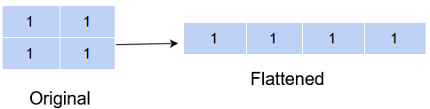

```python
# Swap rows and columns
a = np.arange(6).reshape(2,3)
a
```

```
array([[0, 1, 2],
       [3, 4, 5]])
```

```python
np.transpose(a)
```

```
array([[0, 3],
       [1, 4],
       [2, 5]])
```

```python
a.T
```

```
array([[0, 3],
       [1, 4],
       [2, 5]])
```

```python
# Repeat the elements/array
a = np.array([1,2,3])
np.repeat(a,3)
```

```
array([1, 1, 1, 2, 2, 2, 3, 3, 3])
```

```python
np.tile(a,3)
```

```
array([1, 2, 3, 1, 2, 3, 1, 2, 3])
```

```python
x = np.array([[1,2,3], [4,5,6], [7,8,9], [10, 11, 12]])
x
```

```
array([[ 1,  2,  3],
       [ 4,  5,  6],
       [ 7,  8,  9],
       [10, 11, 12]])
```

```python
y = np.array([0,2,0,1]) # indices
```

```python
# Output - [1 6 7 11]
```

```python
for i in range(len(y)):
    print(x[i,y[i]])
```

```
1
6
7
11
```

```python
x[np.arange(4),y]
```

```
array([ 1,  6,  7, 11])
```

```python
x1 = np.arange(10).reshape(2,5)
y1 = np.arange(11,21).reshape(2,5)
x1
```

```
array([[0, 1, 2, 3, 4],
       [5, 6, 7, 8, 9]])
```

```python
y1
```

```
array([[11, 12, 13, 14, 15],
       [16, 17, 18, 19, 20]])
```

```python
# concatenate
np.concatenate([x1,y1])
```

```
array([[ 0,  1,  2,  3,  4],
       [ 5,  6,  7,  8,  9],
       [11, 12, 13, 14, 15],
       [16, 17, 18, 19, 20]])
```

```python
np.concatenate([x1,y1],axis=1)
```

```
array([[ 0,  1,  2,  3,  4, 11, 12, 13, 14, 15],
       [ 5,  6,  7,  8,  9, 16, 17, 18, 19, 20]])
```

```python
np.vstack([x1,y1])
```

```
array([[ 0,  1,  2,  3,  4],
       [ 5,  6,  7,  8,  9],
       [11, 12, 13, 14, 15],
       [16, 17, 18, 19, 20]])
```

```python
np.hstack([x1,y1])
```

```
array([[ 0,  1,  2,  3,  4, 11, 12, 13, 14, 15],
       [ 5,  6,  7,  8,  9, 16, 17, 18, 19, 20]])
```

#### Joining Arrays Using Stack Functions

- Stacking is same as concatenation, the only difference is that stacking is done along a new axis
- We can concatenate two 1-D arrays along the second axis which would result in putting them one over the other, ie. stacking

```python
# Arithmetic operations
a = np.array([1,2,3,4])
b = np.array([4,5,6,8])
```

```python
np.add(a,b)
```

```
array([ 5,  7,  9, 12])
```

```python
a+b
```

```
array([ 5,  7,  9, 12])
```

```python
np.subtract(a,b)
```

```
array([-3, -3, -3, -4])
```

```python
np.multiply(a,b)
```

```
array([ 4, 10, 18, 32])
```

```python
np.divide(a,b)
```

```
array([0.25, 0.4 , 0.5 , 0.5 ])
```

```python
np.sqrt(a)
```

```
array([1.        , 1.41421356, 1.73205081, 2.        ])
```

```python
print(a)
print(b)
```

```
[1 2 3 4]
[4 5 6 8]
```

```python
np.power(a,b)
```

```
array([    1,    32,   729, 65536], dtype=int32)
```

```python
np.power(a,3)
```

```
array([ 1,  8, 27, 64], dtype=int32)
```

```python
np.mod(a,b)
```

```
array([1, 2, 3, 4], dtype=int32)
```

```python
# In 2D array
x = np.array([[1,2],[3,4]])
x
```

```
array([[1, 2],
       [3, 4]])
```

```python
np.sum(x)
```

```
10
```

```python
np.sum(x,axis=1)
```

```
array([3, 7])
```

```python
np.sum(x,axis=0)
```

```
array([4, 6])
```

```python
dir(np)
```

[output not shown]

[output cut: 553 more lines]

[output not shown]

```python
help(np.sinh)
```

[output not shown]

[output cut: 467 more lines]

[output not shown]

```python
a = np.array([12,13,4,6])
b = a.view()
```

```python
b[0] = 18
```

```python
a
```

```
array([18, 13,  4,  6])
```

```python
b = a.copy()
```

```python
b[2] = 10
```

```python
a
```

```
array([18, 13,  4,  6])
```

#### Splitting NumPy Arrays

- Splitting is reverse operation of Joining, that is breaks one array into multiple arrays
- We use array_split() for splitting arrays, we pass it the array we want to split and the number of splits

```python
a = np.arange(10,34,1).reshape(8,3)
a
```

```
array([[10, 11, 12],
       [13, 14, 15],
       [16, 17, 18],
       [19, 20, 21],
       [22, 23, 24],
       [25, 26, 27],
       [28, 29, 30],
       [31, 32, 33]])
```

```python
np.split(a,4)
```

```
[array([[10, 11, 12],
        [13, 14, 15]]),
 array([[16, 17, 18],
        [19, 20, 21]]),
 array([[22, 23, 24],
        [25, 26, 27]]),
 array([[28, 29, 30],
        [31, 32, 33]])]
```

```python
# Delete 2nd column from the array
a = np.delete(a,1,axis=1)
```

```python
# Insert a column in its place
a = np.insert(a,1,np.arange(8),axis=1)
a
```

[output not shown]

```python
a>20
```

[output not shown]

```python
a[a>20]
```

```
array([21, 22, 24, 25, 27, 28, 30, 31, 33])
```

```python
np.where(a>20,20,0) # If a > 20 replace with 20 else replace with 0
```

[output not shown]

```python
# Common elements in 2 arrays
a = np.array([1,2,3,4,5,6,7,8])
b = np.array([2,3,7,8,8,9,10])
```

```python
res=[]
for i in a:
    for j in b:
        if (i==j and i not in res):

            res.append(i)
res
```

[output not shown]

```python
np.intersect1d(a,b)
```

```
array([2, 3, 7, 8])
```

```python
# Select elements in a which are not present in b
np.setdiff1d(a,b)
```

```
array([1, 4, 5, 6])
```

```python
# Unique elements in array
b = np.array([2,3,7,8,8,8,8,8,89,9,9,9,10])
```

```python
np.unique(b,return_counts=True)
```

```
(array([ 2,  3,  7,  8,  9, 10, 89]),
 array([1, 1, 1, 5, 3, 1, 1], dtype=int64))
```

#### NumPy Arithmetic Operations

Input arrays for performing arithmetic operations such as add(), subtract(), multiply(), and divide() must be either of the same shape or should conform to array broadcasting rules

#### NumPy Array Copy vs View

- The main difference between a copy and a view of an array is that the copy is a new array, and the view is just a view of the original array
- The copy owns the data and any changes made to the copy will not affect original array, and any changes made to the original array will not affect the copy
- The view does not own the data and any changes made to the view will affect the original array, and any changes made to the original array will affect the view

## **Broadcasting**

- arithmetics operations between ndarrays of different sizes or between an ndarray and a simple number!
- Broadcasting essentially *stretches* the *smaller ndarray* so that it matches the **shape of the larger ndarray**.
- Two ndarrays can broadcast are compatible when:
  - Both have the same dimensions
  - Either of the ndarrays has a dimension of 1. The one having a dimension of 1 is broadcast to meet the size requirements of the larger ndarray

```python
a = np.arange(10,20,2)
b = np.array([[3],[3]])
a
```

```
array([10, 12, 14, 16, 18])
```

```python
b
```

```
array([[3],
       [3]])
```

```python
a+b
```

```
array([[13, 15, 17, 19, 21],
       [13, 15, 17, 19, 21]])
```

```python
a*b
```

```
array([[30, 36, 42, 48, 54],
       [30, 36, 42, 48, 54]])
```

```python
np.multiply(a,b)
```

```
array([[30, 36, 42, 48, 54],
       [30, 36, 42, 48, 54]])
```

```python
a/b
```

```
array([[3.33333333, 4.        , 4.66666667, 5.33333333, 6.        ],
       [3.33333333, 4.        , 4.66666667, 5.33333333, 6.        ]])
```